# PCA versus Factor Analysis

Two methods that produce similar-looking output and answer different questions.

## Purpose

Principal component analysis (PCA) and factor analysis (FA) are often confused, and in practice they are sometimes used interchangeably. Both take a large set of correlated variables and return a few dimensions with loadings and scores. But they rest on different models of where the data come from. This walkthrough:

1. Explains the **conceptual and statistical difference** between FA and PCA.
2. Explains what `psych::principal()` is actually doing.
3. Fits a **four-dimension solution both ways** on the same census data and compares the loadings, the variance explained, and the scores.

It builds on the Factor Analysis walkthrough, which uses the same data and explains how the four-factor solution was chosen.

## 1. Two different questions

### Factor analysis

**Question:** *What latent constructs could be generating these observed variables?*

FA is a **measurement model**. Each observed variable is treated as an imperfect indicator of a smaller set of latent factors, plus error:

$$X = \Lambda F + \epsilon$$

- $\Lambda$: loadings, how strongly each variable reflects each factor
- $\epsilon$: uniqueness, the variance not explained by the factors, including measurement error

FA models only the **shared (common) variance** and sets the unique variance aside.

### Principal component analysis

**Question:** *How can we re-express the data with fewer variables while keeping as much of the variance as possible?*

PCA is a **data compression** method, a rotation of the coordinate system. Each component is a weighted sum of the observed variables, chosen to capture as much variance as possible:

$$C = W X$$

The arrows run the other way. In FA, the factors *cause* the variables. In PCA, the components are *built from* the variables. PCA does not model:

- latent causes
- measurement error
- the split between common and unique variance

> **One-line intuition.** FA tries to explain the *covariance* among variables. PCA tries to preserve their *total variance*.

## 2. Common versus total variance

|  | Factor analysis | PCA |
| --- | --- | --- |
| Models latent variables | Yes | No |
| Separates common from unique variance | Yes | No |
| Includes an error term | Yes | No |
| Treats all variance as signal | No | Yes |
| Built for theory and construct measurement | Yes | Sometimes |
| Built for compression and prediction features | Sometimes | Yes |

**The practical implication:** PCA loadings usually look *stronger* than FA loadings. PCA counts all of a variable’s variance, including the noise, as something to explain. FA loadings reflect only the variance a variable shares with the others.

### What loadings and scores mean

**Loadings**

- **FA loading:** how strongly does this variable *measure* the latent factor?
- **PCA loading:** how strongly does this variable *contribute* to the component?

**Scores**

- **FA factor scores:** estimates of each case’s value on the latent trait. They are model-based, and they contain estimation error.
- **PCA component scores:** exact projections of each case onto the component axes. They are geometry, not estimates.

Rotation, such as varimax, makes both solutions easier to read, but **rotating PCA does not turn it into FA**.

## 3. What `psych::principal()` is doing

A common snippet looks like this:

```r
pc4 <- principal(d, nfactors = 4, rotate = "varimax", scores = TRUE)
print.psych(pc4, cut = 0.3, sort = TRUE)
```

This is **PCA**, even though the argument is named `nfactors`. `psych::principal()` extracts principal components, optionally rotates them, and returns component scores. The `psych` package uses the same argument names for both methods so the output is easy to compare, which is also why the two are easy to confuse.

## 4. Setup and data

```r
# Install once if needed:
# install.packages(c("tidyverse", "psych", "GPArotation", "pander"))

library(tidyverse)     # data import and wrangling
library(psych)         # principal(), fa()
library(GPArotation)   # rotation methods
library(pander)        # clean tables in the knitted report

# Read local copies if they sit next to this file; otherwise read from the course repo.
repo <- "https://raw.githubusercontent.com/lecy/econometrics/main/lectures2/data/"
data_path <- if (file.exists("census-data.csv"))    "census-data.csv"    else paste0(repo, "census-data.csv")
dd_path   <- if (file.exists("census-data-dd.csv")) "census-data-dd.csv" else paste0(repo, "census-data-dd.csv")

out_dir <- "fa_vs_pca_outputs"
dir.create(out_dir, showWarnings = FALSE)
```

For comparability, both methods get identical inputs:

1. Median imputation for any missing values (a simple exploratory default)
2. Z-score standardization, so both methods analyze the correlation matrix

```r
dat <- readr::read_csv(data_path, show_col_types = FALSE)
dd  <- readr::read_csv(dd_path,   show_col_types = FALSE)

stopifnot(all(c("LABEL", "VARIABLE") %in% names(dd)))
vars <- dd$LABEL
stopifnot(all(vars %in% names(dat)))

median_impute <- function(x) ifelse(is.na(x), median(x, na.rm = TRUE), x)

X_z <- dat %>%
  dplyr::select(all_of(vars)) %>%
  mutate(across(everything(), ~ median_impute(as.numeric(.x)))) %>%
  scale() %>%
  as.data.frame()

dim(X_z)
```

```
## [1] 1000   30
```

## 5. Fit PCA and FA with four dimensions

Both use `varimax` rotation, so each solution has uncorrelated dimensions and is as easy to read as possible.

### PCA with `psych::principal()`

```r
pca4 <- psych::principal(
  X_z,
  nfactors = 4,           # number of components to keep
  rotate   = "varimax",   # orthogonal rotation
  scores   = TRUE         # return component scores
)
```

### FA with `psych::fa()`

Principal axis factoring (`fm = "pa"`) models only the common variance. As explained in the Factor Analysis walkthrough, this four-factor solution produces a Heywood-case warning, because two pairs of variables are near-duplicates. It is suppressed here.

```r
fa4 <- suppressWarnings(psych::fa(
  X_z,
  nfactors = 4,
  fm       = "pa",          # principal axis factoring
  rotate   = "varimax",
  scores   = "regression"   # regression-method factor scores
))
```

## 6. Line up the dimensions

Neither method guarantees that its first dimension matches the other method’s first dimension. PCA names its rotated components `RC1`–`RC4` and FA names its factors `PA1`–`PA4`, and the numbering doesn’t correspond. Before comparing, **match each factor to the component whose scores correlate with it most strongly**, and flip the sign if needed. The sign of a loading column is arbitrary in both methods.

```r
cross <- cor(fa4$scores, pca4$scores)
round(cross, 2)
```

```
##       RC1  RC4   RC2   RC3
## PA1  0.98 0.04  0.00 -0.02
## PA2 -0.01 0.95 -0.04 -0.01
## PA4  0.00 0.01  0.92  0.00
## PA3  0.00 0.02 -0.02  0.89
```

```r
# For each FA factor, the PCA component it matches best
match_pc <- colnames(cross)[apply(abs(cross), 1, which.max)]
names(match_pc) <- rownames(cross)
stopifnot(!anyDuplicated(match_pc))
match_sign <- sign(cross[cbind(rownames(cross), match_pc)])
names(match_sign) <- rownames(cross)

# Construct names from the Factor Analysis walkthrough
factor_names <- c(PA1 = "ses", PA2 = "stability", PA4 = "immigrant", PA3 = "aging")
fa_order <- names(factor_names)

tibble(
  construct = factor_names[fa_order],
  fa_factor = fa_order,
  pca_component = match_pc[fa_order],
  score_correlation = round(cross[cbind(fa_order, match_pc[fa_order])], 3)
)
```

| construct | fa_factor | pca_component | score_correlation |
| --- | --- | --- | --- |
| ses | PA1 | RC1 | 0.983 |
| stability | PA2 | RC4 | 0.945 |
| immigrant | PA4 | RC2 | 0.922 |
| aging | PA3 | RC3 | 0.886 |

Every factor has a clear partner component. The four dimensions are the same constructs under either method: socioeconomic status, household stability, immigrant communities, and aging population.

## 7. Compare the loadings side by side

```r
L_fa  <- unclass(fa4$loadings)[, fa_order]
L_pca <- sweep(unclass(pca4$loadings)[, match_pc[fa_order]], 2, match_sign[fa_order], `*`)
colnames(L_fa)  <- paste0("FA_",  factor_names[fa_order])
colnames(L_pca) <- paste0("PCA_", factor_names[fa_order])

loadings_compare <- dd %>%
  dplyr::select(LABEL, VARIABLE) %>%
  left_join(as.data.frame(L_pca) %>% rownames_to_column("LABEL"), by = "LABEL") %>%
  left_join(as.data.frame(L_fa)  %>% rownames_to_column("LABEL"), by = "LABEL")

readr::write_csv(loadings_compare, file.path(out_dir, "loadings_pca_vs_fa.csv"))
```

Show each construct’s PCA and FA loadings next to each other, for the variables where either method has a loading of at least 0.40 on that construct.

```r
for (k in unname(factor_names[fa_order])) {
  tab <- loadings_compare %>%
    transmute(LABEL, VARIABLE,
              PCA = .data[[paste0("PCA_", k)]],
              FA  = .data[[paste0("FA_",  k)]],
              pca_minus_fa = abs(PCA) - abs(FA)) %>%   # compare sizes, ignoring sign
    filter(pmax(abs(PCA), abs(FA)) >= 0.40) %>%
    arrange(desc(abs(PCA))) %>%
    mutate(across(c(PCA, FA, pca_minus_fa), ~ sprintf("%.2f", .x)))
  cat("\n### ", k, "\n\n", sep = "")
  pander::pandoc.table(tab, justify = "llrrr", split.table = Inf)
}
```

### ses

| LABEL | VARIABLE | PCA | FA | pca_minus_fa |
| --- | --- | --- | --- | --- |
| pcol12 | Percent with 4-year college degree or more | 0.93 | 0.94 | -0.01 |
| incpc12 | Per capita income | 0.86 | 0.86 | -0.00 |
| pprof12 | Percent professional employees | 0.85 | 0.84 | 0.01 |
| phs12 | Percent with high school degree or less | -0.84 | -0.82 | 0.01 |
| mhmval12 | Median home value | 0.79 | 0.76 | 0.02 |
| hinc12 | Median HH income, total | 0.74 | 0.75 | -0.01 |
| mrent12 | Median rent | 0.69 | 0.66 | 0.03 |
| ppov12 | Percent in poverty, total | -0.51 | -0.51 | 0.00 |
| punemp12 | Percent unemployed | -0.42 | -0.40 | 0.02 |
| psemp12 | Percent self-employed | 0.42 | 0.40 | 0.02 |
| pfhh12 | Percent female-headed families with children | -0.41 | -0.41 | 0.00 |

### stability

| LABEL | VARIABLE | PCA | FA | pca_minus_fa |
| --- | --- | --- | --- | --- |
| pmar12 | Percent currently married, not separated | 0.86 | 0.88 | -0.02 |
| pown12 | Percent owner-occupied units | 0.85 | 0.84 | 0.00 |
| pmulti12 | Percent multi-family units | -0.76 | -0.74 | 0.02 |
| pfhh12 | Percent female-headed families with children | -0.61 | -0.55 | 0.06 |
| pnhblk12 | Percent black, non-Hispanic | -0.60 | -0.52 | 0.08 |
| ppov12 | Percent in poverty, total | -0.58 | -0.55 | 0.03 |
| pnhwht12 | Percent white, non-Hispanic | 0.56 | 0.56 | 0.00 |
| hinc12 | Median HH income, total | 0.46 | 0.45 | 0.01 |
| psemp12 | Percent self-employed | 0.42 | 0.37 | 0.05 |

### immigrant

| LABEL | VARIABLE | PCA | FA | pca_minus_fa |
| --- | --- | --- | --- | --- |
| polang12 | Percent speaking other language at home, age 5 plus | 0.95 | 0.98 | -0.03 |
| phisp12 | Percent Hispanic | 0.89 | 0.84 | 0.05 |
| pfb12 | Percent foreign born | 0.88 | 0.86 | 0.02 |
| pnhwht12 | Percent white, non-Hispanic | -0.58 | -0.53 | 0.05 |
| pvet12 | Percent veteran | -0.42 | -0.35 | 0.07 |

### aging

| LABEL | VARIABLE | PCA | FA | pca_minus_fa |
| --- | --- | --- | --- | --- |
| p75up12 | Percent 75 and older, total | 0.85 | 0.85 | 0.00 |
| p60up12 | Percent 60 and older, total | 0.85 | 0.92 | -0.08 |
| pwds12 | Percent widowed, divorced and separated | 0.58 | 0.53 | 0.05 |
| pflabf12 | Percent female labor force participation | -0.55 | -0.42 | 0.12 |
| p18und12 | Percent 17 and under, total | -0.51 | -0.41 | 0.09 |
| pvac12 | Percent vacant units | 0.45 | 0.35 | 0.10 |

The `pca_minus_fa` column compares the size of the two loadings, ignoring sign. Two patterns stand out:

- **Strong indicators barely change.** College degrees, income, and homeownership load within about 0.03 of each other under both methods. When most of a variable’s variance is shared, there is little unique variance for the two methods to disagree about.
- **Weaker indicators load higher in PCA.** Female labor force participation, children, and vacant units on the aging dimension, and percent Black on the stability dimension, gain roughly 0.08 to 0.12 under PCA. FA sets much of their variance aside as unique; PCA counts it. This is the common-versus-total-variance difference in action.

The main exceptions run the other way: percent speaking another language and percent 60 and older load *higher* in FA. These are the near-duplicate variables behind the Heywood warning, where FA treats essentially all of the variance as shared.

## 8. Variance explained and communalities

Both methods report a **communality** ($h^2$) for each variable: the share of its variance captured by the four dimensions. In FA, the rest is uniqueness. In PCA, the rest is simply variance the four components left behind.

```r
comm <- tibble(
  LABEL   = names(fa4$communality),
  h2_pca  = unname(pca4$communality),
  h2_fa   = unname(fa4$communality)
) %>%
  left_join(dd, by = "LABEL") %>%
  relocate(LABEL, VARIABLE)

summarise(comm,
          mean_h2_pca = mean(h2_pca),
          mean_h2_fa  = mean(h2_fa),
          share_pca_higher = mean(h2_pca > h2_fa))
```

| mean_h2_pca | mean_h2_fa | share_pca_higher |
| --- | --- | --- |
| 0.5956629 | 0.5544046 | 0.8333333 |

```r
# Variables where FA reports the higher communality
comm %>% filter(h2_fa >= h2_pca) %>% mutate(across(c(h2_pca, h2_fa), ~ round(.x, 2)))
```

| LABEL | VARIABLE | h2_pca | h2_fa |
| --- | --- | --- | --- |
| polang12 | Percent speaking other language at home, age 5 plus | 0.94 | 1.00 |
| pcol12 | Percent with 4-year college degree or more | 0.89 | 0.91 |
| hinc12 | Median HH income, total | 0.83 | 0.83 |
| p60up12 | Percent 60 and older, total | 0.88 | 1.00 |
| pmar12 | Percent currently married, not separated | 0.85 | 0.88 |

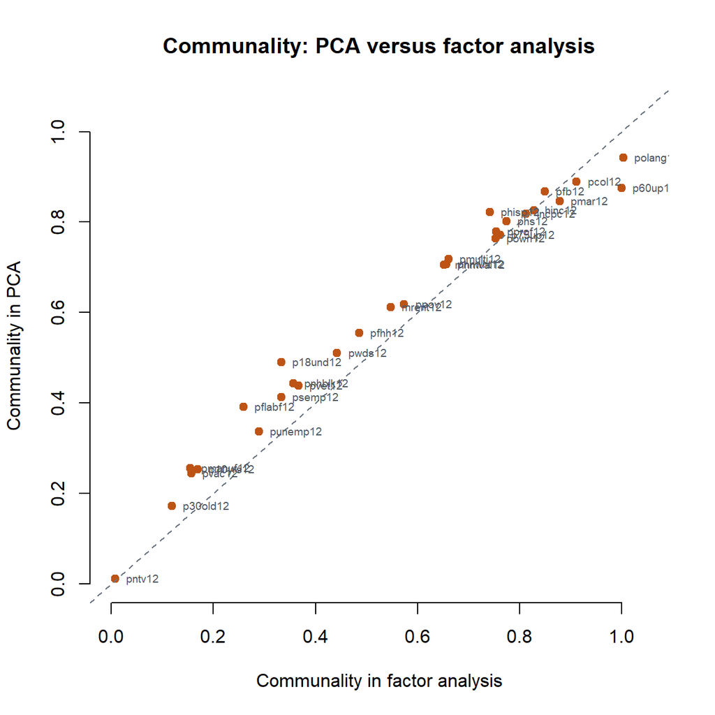

```r
lim <- c(0, 1.05)
plot(comm$h2_fa, comm$h2_pca, xlim = lim, ylim = lim,
     pch = 19, col = "#bd5416", bty = "n",
     xlab = "Communality in factor analysis",
     ylab = "Communality in PCA",
     main = "Communality: PCA versus factor analysis")
abline(0, 1, lty = 2, col = "#6d7681")
text(comm$h2_fa, comm$h2_pca, comm$LABEL, pos = 4, cex = 0.6, col = "#4d565f")
```

Points above the dashed line are variables where PCA claims more variance than FA, which is 83% of them. The gap tends to be widest for variables with low FA communalities, such as percent 17 and under and female labor force participation. Those are the noisy indicators, where FA attributes most of the variance to uniqueness and PCA keeps it. The few points below the line are the near-duplicates and a handful of very strong indicators.

The same pattern shows up in total variance explained:

```r
round(pca4$Vaccounted[c("SS loadings", "Proportion Var", "Cumulative Var"), ], 2)
```

```
##                 RC1  RC4  RC2  RC3
## SS loadings    6.32 4.85 3.56 3.14
## Proportion Var 0.21 0.16 0.12 0.10
## Cumulative Var 0.21 0.37 0.49 0.60
```

```r
round(fa4$Vaccounted[c("SS loadings", "Proportion Var", "Cumulative Var"), ], 2)
```

```
##                 PA1  PA2  PA4  PA3
## SS loadings    6.13 4.44 3.27 2.79
## Proportion Var 0.20 0.15 0.11 0.09
## Cumulative Var 0.20 0.35 0.46 0.55
```

## 9. Compare the scores

Both methods produce a score on each dimension for every neighborhood. How similar are they, and how independent is each set?

```r
scores_fa <- as.data.frame(fa4$scores)[, fa_order]
names(scores_fa) <- paste0("FA_", factor_names[fa_order])

scores_pca <- sweep(as.data.frame(pca4$scores)[, match_pc[fa_order]], 2, match_sign[fa_order], `*`) %>%
  as.data.frame()
names(scores_pca) <- paste0("PCA_", factor_names[fa_order])

# Within-method correlations
round(cor(scores_pca), 3)
```

```
##               PCA_ses PCA_stability PCA_immigrant PCA_aging
## PCA_ses             1             0             0         0
## PCA_stability       0             1             0         0
## PCA_immigrant       0             0             1         0
## PCA_aging           0             0             0         1
```

```r
round(cor(scores_fa), 3)
```

```
##              FA_ses FA_stability FA_immigrant FA_aging
## FA_ses        1.000       -0.002        0.000    0.013
## FA_stability -0.002        1.000        0.026   -0.031
## FA_immigrant  0.000        0.026        1.000    0.007
## FA_aging      0.013       -0.031        0.007    1.000
```

```r
# Matched pairs across methods
round(diag(cor(scores_pca, scores_fa)), 3)
```

```
## [1] 0.983 0.945 0.922 0.886
```

```r
readr::write_csv(scores_pca, file.path(out_dir, "scores_pca4.csv"))
readr::write_csv(scores_fa,  file.path(out_dir, "scores_fa4.csv"))
readr::write_csv(
  as.data.frame(round(cor(scores_pca, scores_fa), 3)) %>% rownames_to_column("PCA_component"),
  file.path(out_dir, "score_correlations_pca_vs_fa.csv")
)
```

Three things to notice:

- **PCA component scores are exactly uncorrelated.** They are exact projections onto orthogonal axes.
- **FA factor scores are only approximately uncorrelated.** The factors are orthogonal, but the scores are *estimates* of them, and estimation error introduces small correlations.
- **The matched scores are highly correlated** across methods (roughly 0.9 or higher). For a large, well-structured set of variables, the two methods agree on *which* dimensions exist. They disagree about how much of each variable is signal.

## 10. When to use which

### Prefer factor analysis when

- You want interpretable **latent constructs** that you can name and defend
- You care about **measurement validity**, meaning the split between common and unique variance
- You treat the variables as indicators of underlying neighborhood conditions

### Prefer PCA when

- You want compact features for **prediction** or **dimension reduction**
- You want to keep as much of the total variance as possible in fewer dimensions
- You don’t need a latent-variable or measurement interpretation

### A practical workflow

Many projects:

1. Run PCA as a quick check of the structure.
2. Run FA to interpret and report the constructs.
3. Use FA factor scores, or PCA components, as predictors in later models.

## Outputs

Knitting this file writes four files to `fa_vs_pca_outputs/`:

- `loadings_pca_vs_fa.csv`: aligned PCA and FA loadings for every variable
- `scores_pca4.csv`: aligned PCA component scores
- `scores_fa4.csv`: FA factor scores
- `score_correlations_pca_vs_fa.csv`: correlations between the two sets of scores